# ML01-Predicting_Churn_Telcom

Ranalytics

16/06/2021

# Business Understand

Telco é uma empresa de telecomunicações americana, reconhecida por serviços residenciais como televisão por assinatura, acesso à internet e telefonia fixa.  
Em uma reunião da empresa entre os gerentes e CEO, foi averiguado que taxa de churn dos clientes está em 26% o que é muito alto , quando o aceitavel seria algo em torno de 5%.  
Sendo assim o CEO pediu ao gerente da área de Data Science para criar uma solução que diminua a taxa de churn.

## Challenges

- Entender o porque do desligamento dos clientes.
- Como se antecipar a clientes que tem intensão de sair da empresa e assim oferecer incentivos para que esse cliente continue conosco e assim diminuir o custo de aquisição de novos clientes.

# Analytic approach

- EDA (Exploration Data Analysis).
- Criar um modelo de Classificação.
- Ordenar a tabela de clientes selecionando os cliente mais propensos a sair.
- Maximizar o custo de aquisição dos clientes.

# Data requirements

## Loading packages

```r
library(tidyverse)
library(DT)

theme_set(theme_minimal())
```

## Functions

```r
predmodel_datatable <- function(dataset){
  dataset %>%
      datatable(escape = FALSE,
                rownames = FALSE,
                options = list(dom = 'ltipr',
                               ordering = FALSE,
                               scrollY = "200px",
                               scrollX = TRUE,
                               scrollCollapse = TRUE,
                               paging = FALSE,
                               searchHighlight = TRUE))
}
```

# Data Collection

## Loading data

```r
df_raw <- data.table::fread("~/repos/Increasing-the-Retention-Rate/Data/WA_Fn-UseC_-Telco-Customer-Churn.csv")

head(df_raw) %>%
  predmodel_datatable()
```

| customerID | gender | SeniorCitizen | Partner | Dependents | tenure | PhoneService | MultipleLines | InternetService | OnlineSecurity | OnlineBackup | DeviceProtection | TechSupport | StreamingTV | StreamingMovies | Contract | PaperlessBilling | PaymentMethod | MonthlyCharges | TotalCharges | Churn |
| --- | --- | --- | --- | --- | --- | --- | --- | --- | --- | --- | --- | --- | --- | --- | --- | --- | --- | --- | --- | --- |
| 7590-VHVEG | Female | 0 | Yes | No | 1 | No | No phone service | DSL | No | Yes | No | No | No | No | Month-to-month | Yes | Electronic check | 29.85 | 29.85 | No |
| 5575-GNVDE | Male | 0 | No | No | 34 | Yes | No | DSL | Yes | No | Yes | No | No | No | One year | No | Mailed check | 56.95 | 1889.5 | No |
| 3668-QPYBK | Male | 0 | No | No | 2 | Yes | No | DSL | Yes | Yes | No | No | No | No | Month-to-month | Yes | Mailed check | 53.85 | 108.15 | Yes |
| 7795-CFOCW | Male | 0 | No | No | 45 | No | No phone service | DSL | Yes | No | Yes | Yes | No | No | One year | No | Bank transfer (automatic) | 42.3 | 1840.75 | No |
| 9237-HQITU | Female | 0 | No | No | 2 | Yes | No | Fiber optic | No | No | No | No | No | No | Month-to-month | Yes | Electronic check | 70.7 | 151.65 | Yes |
| 9305-CDSKC | Female | 0 | No | No | 8 | Yes | Yes | Fiber optic | No | No | Yes | No | Yes | Yes | Month-to-month | Yes | Electronic check | 99.65 | 820.5 | Yes |

# Data understand

## Data Description Table

```r
descricao <-  c("indentificador unico do cliente.  ","Se cliente é homem ou mulher.  ","Se cliente é idoso ou não.  ",
             "Se cliente é casado ou não.  ","Se cliente possui dependentes ou não.  ",
             "Número de meses que o cliente permaneceu na empresa.  ","Se o cliente tem serviço de telefônico ou não.  ",
             "Se o cliente tem várias linhas ou não.   ", "Se cliente tem serviço de internet.  ",
             "Se o cliente tem serviço de anti-virus ou não.  ",
             "Indica se o cliente assina um serviço de backup online adicional fornecido pela empresa.  ",
             "Indica se o cliente assina um plano de proteção de dispositivo adicional para seu equipamento de Internet fornecido pela empresa.",  "Indica se o cliente assina um plano de suporte técnico adicional da empresa com tempos de espera reduzidos.  ",
             "Indica se o cliente usa seu serviço de Internet para transmitir programas de televisão de um provedor terceirizado.  ",
             "Indica se o cliente usa seu serviço de Internet para transmitir filmes de um provedor terceirizado.  ",
             "Indica o tipo de contrato atual do cliente: mês a mês, um ano, dois anos.  ",
             "Indica se o cliente escolheu faturamento sem boleto.  ",
             "Indica como o cliente paga sua fatura: saque bancário, cartão de crédito, cheque enviado.  ",
             "Indica a cobrança mensal total atual do cliente por todos os seus serviços da empresa.  ",
             "Indica as cobranças totais do cliente, calculadas até o final do trimestre especificado acima. ",
             "Indica se cliente deixou a empresa ou não.")

tbl_descricao <- tibble(variavel = colnames(df_raw),
       descricao = descricao)

tbl_descricao %>%
  predmodel_datatable()
```

| variavel | descricao |
| --- | --- |
| customerID | indentificador unico do cliente. |
| gender | Se cliente é homem ou mulher. |
| SeniorCitizen | Se cliente é idoso ou não. |
| Partner | Se cliente é casado ou não. |
| Dependents | Se cliente possui dependentes ou não. |
| tenure | Número de meses que o cliente permaneceu na empresa. |
| PhoneService | Se o cliente tem serviço de telefônico ou não. |
| MultipleLines | Se o cliente tem várias linhas ou não. |
| InternetService | Se cliente tem serviço de internet. |
| OnlineSecurity | Se o cliente tem serviço de anti-virus ou não. |

[output cut: 11 more lines]

## Number of rows and columns

```r
print(paste("Number of Rows: " ,nrow(df_raw)))
```

```
[1] "Number of Rows:  7043"
```

```r
print(paste("Number of Cols: " ,ncol(df_raw)))
```

```
[1] "Number of Cols:  21"
```

## Data types

```r
glimpse(df_raw)
```

```
Rows: 7,043
Columns: 21
$ customerID       <chr> "7590-VHVEG", "5575-GNVDE", "3668-QPYBK", "7795-CFOCW…
$ gender           <chr> "Female", "Male", "Male", "Male", "Female", "Female",…
$ SeniorCitizen    <int> 0, 0, 0, 0, 0, 0, 0, 0, 0, 0, 0, 0, 0, 0, 0, 0, 0, 0,…
$ Partner          <chr> "Yes", "No", "No", "No", "No", "No", "No", "No", "Yes…
$ Dependents       <chr> "No", "No", "No", "No", "No", "No", "Yes", "No", "No"…
$ tenure           <int> 1, 34, 2, 45, 2, 8, 22, 10, 28, 62, 13, 16, 58, 49, 2…
$ PhoneService     <chr> "No", "Yes", "Yes", "No", "Yes", "Yes", "Yes", "No", …
$ MultipleLines    <chr> "No phone service", "No", "No", "No phone service", "…
$ InternetService  <chr> "DSL", "DSL", "DSL", "DSL", "Fiber optic", "Fiber opt…
$ OnlineSecurity   <chr> "No", "Yes", "Yes", "Yes", "No", "No", "No", "Yes", "…
$ OnlineBackup     <chr> "Yes", "No", "Yes", "No", "No", "No", "Yes", "No", "N…
$ DeviceProtection <chr> "No", "Yes", "No", "Yes", "No", "Yes", "No", "No", "Y…
$ TechSupport      <chr> "No", "No", "No", "Yes", "No", "No", "No", "No", "Yes…
$ StreamingTV      <chr> "No", "No", "No", "No", "No", "Yes", "Yes", "No", "Ye…
$ StreamingMovies  <chr> "No", "No", "No", "No", "No", "Yes", "No", "No", "Yes…
$ Contract         <chr> "Month-to-month", "One year", "Month-to-month", "One …
$ PaperlessBilling <chr> "Yes", "No", "Yes", "No", "Yes", "Yes", "Yes", "No", …
$ PaymentMethod    <chr> "Electronic check", "Mailed check", "Mailed check", "…
$ MonthlyCharges   <dbl> 29.85, 56.95, 53.85, 42.30, 70.70, 99.65, 89.10, 29.7…
$ TotalCharges     <dbl> 29.85, 1889.50, 108.15, 1840.75, 151.65, 820.50, 1949…
$ Churn            <chr> "No", "No", "Yes", "No", "Yes", "Yes", "No", "No", "Y…
```

## Checking Missing values

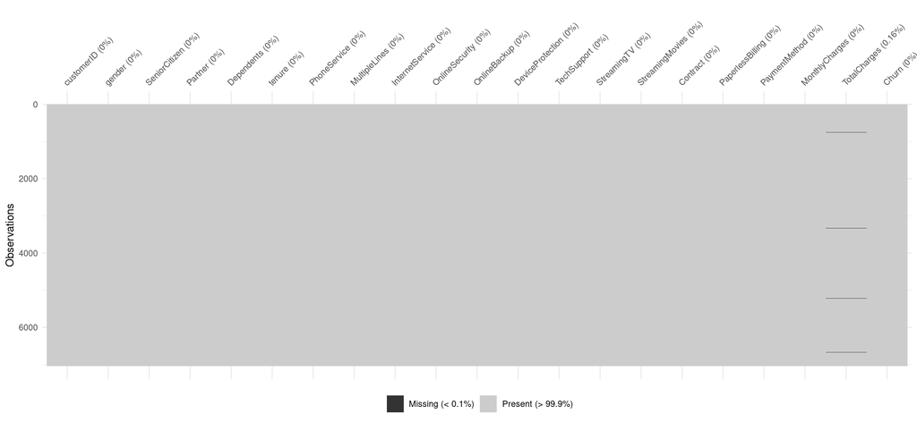

```r
naniar::vis_miss(df_raw)
```

```r
colSums(is.na(df_raw))
```

```
      customerID           gender    SeniorCitizen          Partner
               0                0                0                0
      Dependents           tenure     PhoneService    MultipleLines
               0                0                0                0
 InternetService   OnlineSecurity     OnlineBackup DeviceProtection
               0                0                0                0
     TechSupport      StreamingTV  StreamingMovies         Contract
               0                0                0                0
PaperlessBilling    PaymentMethod   MonthlyCharges     TotalCharges
               0                0                0               11
           Churn
               0
```

Apenas a variavel **TotalCharges** possui 11 valores ausentes representando apenas 0.16% da base de dados.

### Change type and Fillout:

- Todas as variaveis que estiverem com tipo **character** serão convertidas em **factor**.
- Excluir os 11 valores ausentes da variavel **TotalCharges**.
- Definir na variavel **churn** **Yes** como a classe positiva.
- Nome das variaveis serão aplicadas o metodo snake case.

```r
df1 <- df_raw %>%
  mutate_if(is.character, as.factor) %>%
  drop_na(TotalCharges) %>%
  mutate(Churn = forcats::fct_relevel(Churn, "Yes","No")) %>%
  janitor::clean_names()
```

## Summary Statistical

```r
summary(df1)
```

```
     customer_id      gender     senior_citizen   partner    dependents
 0002-ORFBO:   1   Female:3483   Min.   :0.0000   No :3639   No :4933
 0003-MKNFE:   1   Male  :3549   1st Qu.:0.0000   Yes:3393   Yes:2099
 0004-TLHLJ:   1                 Median :0.0000
 0011-IGKFF:   1                 Mean   :0.1624
 0013-EXCHZ:   1                 3rd Qu.:0.0000
 0013-MHZWF:   1                 Max.   :1.0000
 (Other)   :7026
     tenure      phone_service          multiple_lines    internet_service
 Min.   : 1.00   No : 680      No              :3385   DSL        :2416
 1st Qu.: 9.00   Yes:6352      No phone service: 680   Fiber optic:3096
 Median :29.00                 Yes             :2967   No         :1520
 Mean   :32.42
 3rd Qu.:55.00
 Max.   :72.00

            online_security             online_backup
 No                 :3497   No                 :3087
 No internet service:1520   No internet service:1520
 Yes                :2015   Yes                :2425




           device_protection              tech_support
 No                 :3094    No                 :3472
 No internet service:1520    No internet service:1520
 Yes                :2418    Yes                :2040




              streaming_tv             streaming_movies           contract
 No                 :2809   No                 :2781    Month-to-month:3875
 No internet service:1520   No internet service:1520    One year      :1472
 Yes                :2703   Yes                :2731    Two year      :1685




 paperless_billing                   payment_method monthly_charges
 No :2864          Bank transfer (automatic):1542   Min.   : 18.25
 Yes:4168          Credit card (automatic)  :1521   1st Qu.: 35.59
                   Electronic check         :2365   Median : 70.35
                   Mailed check             :1604   Mean   : 64.80
                                                    3rd Qu.: 89.86
                                                    Max.   :118.75

 total_charges    churn
 Min.   :  18.8   Yes:1869
 1st Qu.: 401.4   No :5163
 Median :1397.5
 Mean   :2283.3
 3rd Qu.:3794.7
 Max.   :8684.8
```

As variaveis abaixo possuem informações duplicadas:

- multiple_lines
- online_security
- online_backup
- device_protection
- tech_support
- streaming_tv
- streaming_movies

### Removing Duplicated

```r
df1 <- df1 %>%

  mutate( multiple_lines = recode( multiple_lines,"No phone service" = "No" ) ) %>% # substituindo "No phone service" por "No"
  mutate_at( vars( online_security:streaming_movies ),
            funs( recode( .,"No internet service" = "No" ) ) ) %>% # substituindo "No internet service" por "No"
  mutate( payment_method = recode( payment_method,"Bank transfer (automatic)"= "Bank transfer" ,
                                                  "Credit card (automatic)"  = "Credit card"))# removendo " (automatic) "
```

## Distribution of Numerical Variables

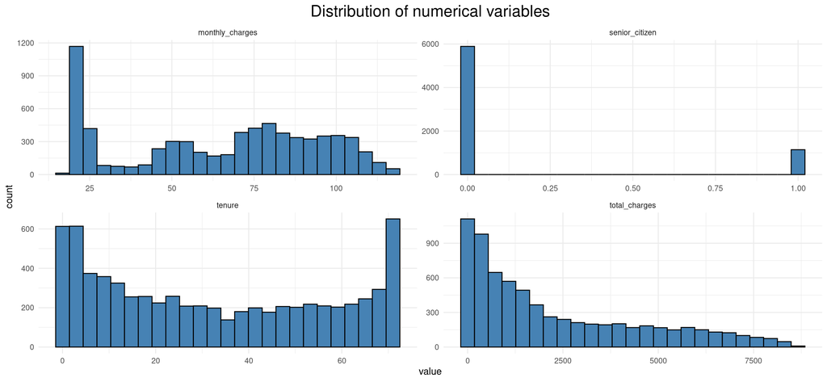

```r
df1 %>%
  keep(is.numeric) %>%
  gather() %>%
  ggplot(aes(value)) +
    facet_wrap(~ key, scales = "free") +
    geom_histogram(col= "black", fill="steelblue", bins = 25)+
    scale_y_continuous(labels = function(x) format(x, scientific = FALSE))+
  labs(title = "Distribution of numerical variables")+
  theme(plot.title = element_text(hjust = 0.5, size = 18))
```

## Distribution of Categorical Variables

[figure not shown]

```r
df1 %>%
  keep(is.factor) %>%
  select(-customer_id) %>%
  gather() %>%
  ggplot(aes(value)) +
    facet_wrap(~ key, scales = "free") +
    geom_bar(col= "black", fill="steelblue", bins = 25)+
    scale_y_continuous(labels = function(x) format(x, scientific = FALSE))+
  labs(title = "Distribution of numerical variables")+
  theme(plot.title = element_text(hjust = 0.5, size = 18))+
  theme(axis.text.x = element_text(angle = 90, vjust = 0.5, hjust=1))
```

## Feature Engineering

## EDA

### Creation of Hypotheses

# Data preparation

## Rescaling

## Transformation

## Encoding

## Feature Selection

# Modeling

## Split data

## Models

# Evaluation

## Comparing Models

### Single performance

### Real perfromance

## Hyperparameter Fine Tuning

## Business Error Interpretation and Translation

# Deployment

# Feedback